# Shashi_proj2_Supervised_Learning_Personal_Loan_Campaign_Modelling

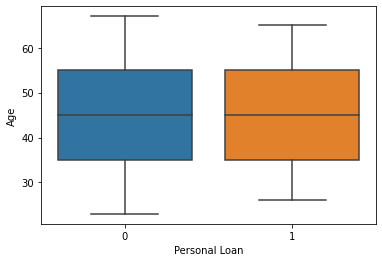

```python
sns.boxplot(data=pdata,x='Personal Loan',y='Age')
plt.show()
```

There distrubution is even among age group that have opted for the loan and not opted for the personal loan. Looks like Age and Experience are highly correlated.

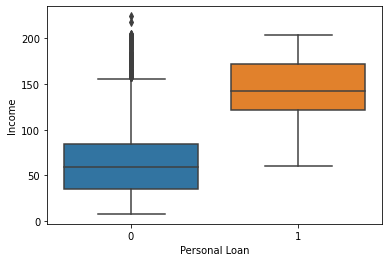

```python
sns.boxplot(data=pdata,x='Personal Loan',y='Income')
plt.show()
```

The high income group that have not shown interest in the persomal loan are mosly outliers. Higher the income there is more interest in the loan.

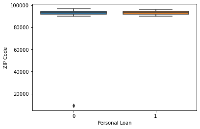

```python
sns.boxplot(data=pdata,x='Personal Loan',y='ZIP Code')
plt.show()
```

The distribution looks even for interest based on the geographical location.

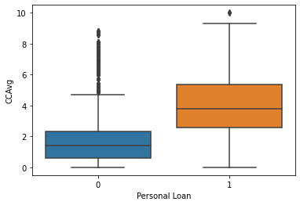

```python
sns.boxplot(data=pdata,x='Personal Loan',y='CCAvg')
plt.show()
```

People with higher Credit card average showed more interest for the personal loan.

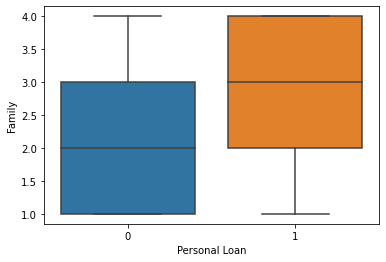

```python
sns.boxplot(data=pdata,x='Personal Loan',y='Family')
plt.show()
```

People with a larger family size showed more interest in the loan.

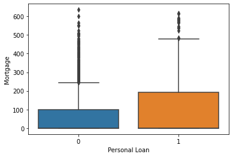

```python
sns.boxplot(data=pdata,x='Personal Loan',y='Mortgage')
plt.show()
```

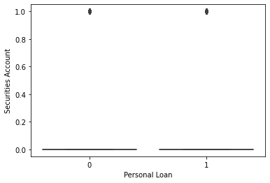

```python
sns.boxplot(data=pdata,x='Personal Loan',y='Securities Account')
plt.show()
```

Very weak correation here.

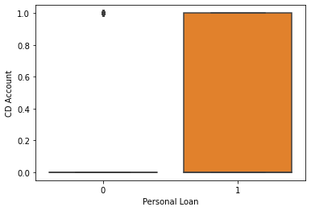

```python
sns.boxplot(data=pdata,x='Personal Loan',y='CD Account')
plt.show()
```

People with CD account seems to be more interested in the Personal loan.

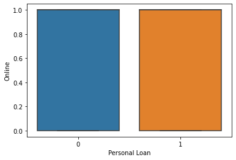

```python
sns.boxplot(data=pdata,x='Personal Loan',y='Online')
plt.show()
```

Weak correation here.

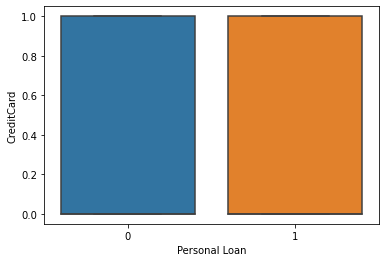

```python
sns.boxplot(data=pdata,x='Personal Loan',y='CreditCard')
plt.show()

#['ID', 'Age', 'Experience', 'Income', 'ZIP Code', 'Family', 'CCAvg', 'Education',
#'Mortgage', 'Personal Loan', 'Securities Account', 'CD Account', 'Online', 'CreditCard']
```

Weak correation here.

```python
pdata.corr() # It will show correlation matrix
```

|  | ID | Age | Experience | Income | ZIP Code | Family | CCAvg | Education | Mortgage | Personal Loan | Securities Account | CD Account | Online | CreditCard |
| --- | --- | --- | --- | --- | --- | --- | --- | --- | --- | --- | --- | --- | --- | --- |
| ID | 1.000000 | -0.008473 | -0.008326 | -0.017695 | 0.013432 | -0.016797 | -0.024675 | 0.021463 | -0.013920 | -0.024801 | -0.016972 | -0.006909 | -0.002528 | 0.017028 |
| Age | -0.008473 | 1.000000 | 0.994215 | -0.055269 | -0.029216 | -0.046418 | -0.052012 | 0.041334 | -0.012539 | -0.007726 | -0.000436 | 0.008043 | 0.013702 | 0.007681 |
| Experience | -0.008326 | 0.994215 | 1.000000 | -0.046574 | -0.028626 | -0.052563 | -0.050077 | 0.013152 | -0.010582 | -0.007413 | -0.001232 | 0.010353 | 0.013898 | 0.008967 |
| Income | -0.017695 | -0.055269 | -0.046574 | 1.000000 | -0.016410 | -0.157501 | 0.645984 | -0.187524 | 0.206806 | 0.502462 | -0.002616 | 0.169738 | 0.014206 | -0.002385 |
| ZIP Code | 0.013432 | -0.029216 | -0.028626 | -0.016410 | 1.000000 | 0.011778 | -0.004061 | -0.017377 | 0.007383 | 0.000107 | 0.004704 | 0.019972 | 0.016990 | 0.007691 |
| Family | -0.016797 | -0.046418 | -0.052563 | -0.157501 | 0.011778 | 1.000000 | -0.109275 | 0.064929 | -0.020445 | 0.061367 | 0.019994 | 0.014110 | 0.010354 | 0.011588 |
| CCAvg | -0.024675 | -0.052012 | -0.050077 | 0.645984 | -0.004061 | -0.109275 | 1.000000 | -0.136124 | 0.109905 | 0.366889 | 0.015086 | 0.136534 | -0.003611 | -0.006689 |
| Education | 0.021463 | 0.041334 | 0.013152 | -0.187524 | -0.017377 | 0.064929 | -0.136124 | 1.000000 | -0.033327 | 0.136722 | -0.010812 | 0.013934 | -0.015004 | -0.011014 |
| Mortgage | -0.013920 | -0.012539 | -0.010582 | 0.206806 | 0.007383 | -0.020445 | 0.109905 | -0.033327 | 1.000000 | 0.142095 | -0.005411 | 0.089311 | -0.005995 | -0.007231 |
| Personal Loan | -0.024801 | -0.007726 | -0.007413 | 0.502462 | 0.000107 | 0.061367 | 0.366889 | 0.136722 | 0.142095 | 1.000000 | 0.021954 | 0.316355 | 0.006278 | 0.002802 |
| Securities Account | -0.016972 | -0.000436 | -0.001232 | -0.002616 | 0.004704 | 0.019994 | 0.015086 | -0.010812 | -0.005411 | 0.021954 | 1.000000 | 0.317034 | 0.012627 | -0.015028 |
| CD Account | -0.006909 | 0.008043 | 0.010353 | 0.169738 | 0.019972 | 0.014110 | 0.136534 | 0.013934 | 0.089311 | 0.316355 | 0.317034 | 1.000000 | 0.175880 | 0.278644 |
| Online | -0.002528 | 0.013702 | 0.013898 | 0.014206 | 0.016990 | 0.010354 | -0.003611 | -0.015004 | -0.005995 | 0.006278 | 0.012627 | 0.175880 | 1.000000 | 0.004210 |
| CreditCard | 0.017028 | 0.007681 | 0.008967 | -0.002385 | 0.007691 | 0.011588 | -0.006689 | -0.011014 | -0.007231 | 0.002802 | -0.015028 | 0.278644 | 0.004210 | 1.000000 |

```python
# However we want to see correlation in graphical representation so below is function for that
def plot_corr(df, size=20):
    corr = df.corr()
    fig, ax = plt.subplots(figsize=(size, size))
    ax.matshow(corr)
    plt.xticks(range(len(corr.columns)), corr.columns)
    plt.yticks(range(len(corr.columns)), corr.columns)
    for (i, j), z in np.ndenumerate(corr):
        ax.text(j, i, '{:0.1f}'.format(z), ha='center', va='center')
```

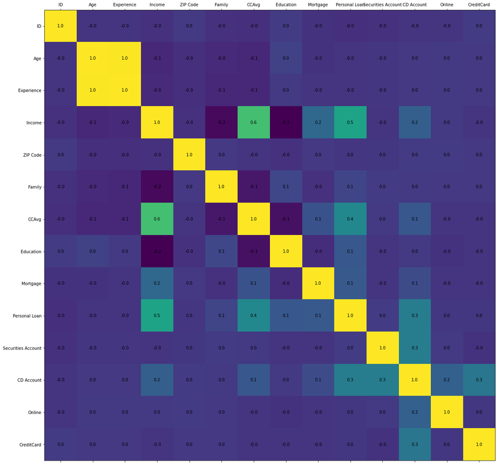

```python
plot_corr(pdata)
```

In above plot yellow colour represents maximum correlation and blue colour represents minimum correlation. We can see that Age and Experience are highly correlated. Income to credit card card average seems to be correlated. Personal loan to Income and Personal loan to Credit Card Average seems to be more correlated. CD Accounts and Personal loans seems to be correlated from the above heat map.

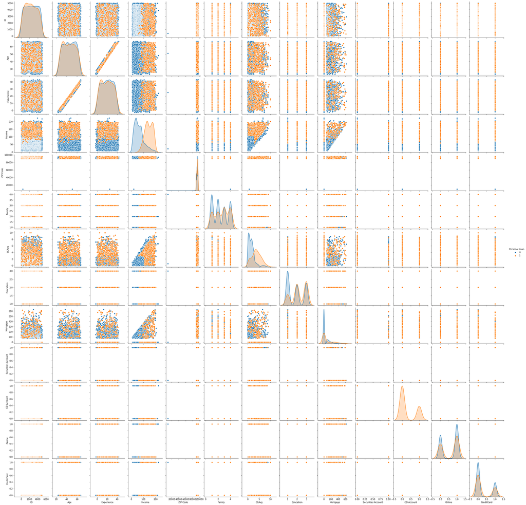

```python
sns.pairplot(pdata,diag_kind='kde', hue='Personal Loan')
```

```python
#Get data model ready
per_loan_df = pdata.drop('ID', axis =1 ) # dropping this column as it will be 1-1 mapping anyways
per_loan_df.head()
```

|  | Age | Experience | Income | ZIP Code | Family | CCAvg | Education | Mortgage | Personal Loan | Securities Account | CD Account | Online | CreditCard |
| --- | --- | --- | --- | --- | --- | --- | --- | --- | --- | --- | --- | --- | --- |
| 0 | 25 | 1 | 49 | 91107 | 4 | 1.6 | 1 | 0 | 0 | 1 | 0 | 0 | 0 |
| 1 | 45 | 19 | 34 | 90089 | 3 | 1.5 | 1 | 0 | 0 | 1 | 0 | 0 | 0 |
| 2 | 39 | 15 | 11 | 94720 | 1 | 1.0 | 1 | 0 | 0 | 0 | 0 | 0 | 0 |
| 3 | 35 | 9 | 100 | 94112 | 1 | 2.7 | 2 | 0 | 0 | 0 | 0 | 0 | 0 |
| 4 | 35 | 8 | 45 | 91330 | 4 | 1.0 | 2 | 0 | 0 | 0 | 0 | 0 | 1 |

```python
per_loan_df['ZIP Code'].value_counts(normalize=True)
```

```
94720    0.0338
94305    0.0254
95616    0.0232
90095    0.0142
93106    0.0114
          ...
96145    0.0002
94970    0.0002
94598    0.0002
90068    0.0002
94087    0.0002
Name: ZIP Code, Length: 467, dtype: float64
```

```python
per_loan_df['Mortgage'].value_counts(normalize=True)
```

```
0      0.6924
98     0.0034
103    0.0032
119    0.0032
83     0.0032
        ...
541    0.0002
509    0.0002
505    0.0002
485    0.0002
577    0.0002
Name: Mortgage, Length: 347, dtype: float64
```

```python
#The ZIP Code is highly skewed - so we will delete this column
per_loan_df.drop(['ZIP Code'], axis=1, inplace=True)
```

```python
##The Mortgage is highly skewed - so we will delete this column
per_loan_df.drop(['Mortgage'], axis=1, inplace=True)
```

```python
## Define X and Y variables
X = per_loan_df.drop('Personal Loan', axis=1)
Y = per_loan_df[['Personal Loan']]
```

## Split the data into training and test set in the ratio of 70:30 respectively

```python
##Split into training and test set
from sklearn.model_selection import train_test_split

X_train, X_test, y_train, y_test = train_test_split(X, Y, test_size=0.30,random_state=1)

X_train.head()
```

|  | Age | Experience | Income | Family | CCAvg | Education | Securities Account | CD Account | Online | CreditCard |
| --- | --- | --- | --- | --- | --- | --- | --- | --- | --- | --- |
| 1334 | 47 | 22 | 35 | 2 | 1.3 | 1 | 0 | 0 | 1 | 0 |
| 4768 | 38 | 14 | 39 | 1 | 2.0 | 2 | 0 | 0 | 1 | 0 |
| 65 | 59 | 35 | 131 | 1 | 3.8 | 1 | 0 | 0 | 1 | 1 |
| 177 | 29 | 3 | 65 | 4 | 1.8 | 2 | 0 | 0 | 0 | 0 |
| 4489 | 39 | 13 | 21 | 3 | 0.2 | 2 | 0 | 0 | 1 | 0 |

Lets check split of data

```python
print("{0:0.2f}% data is in training set".format((len(X_train)/len(per_loan_df.index)) * 100))
print("{0:0.2f}% data is in test set".format((len(X_test)/len(per_loan_df.index)) * 100))
```

```
70.00% data is in training set
30.00% data is in test set
```

## Use Logistic Regression model to predict whether the customer will take personal loan or not. Print all the metrics related for evaluating the model performance

```python
from sklearn.metrics import confusion_matrix, recall_score, precision_score, f1_score, roc_auc_score,accuracy_score

from sklearn.linear_model import LogisticRegression

# Fit the model on train
model = LogisticRegression(solver="liblinear")
model.fit(X_train, y_train)
#predict on test
y_predict = model.predict(X_test)


coef_df = pd.DataFrame(model.coef_)
coef_df['intercept'] = model.intercept_
print(coef_df)
```

```
          0         1         2        3         4         5         6  \
0 -0.403941  0.402322  0.049507  0.65278  0.158268  1.650813 -0.897782

          7         8         9  intercept
0  3.265231 -0.575493 -1.010603  -2.395909
```

```python
#Test accuracy calculation
model_score = model.score(X_test, y_test)
print(model_score)
```

```
0.9446666666666667
```

```python
## function to get confusion matrix in a proper format
def draw_cm( actual, predicted ):
    cm = confusion_matrix( actual, predicted)
    sns.heatmap(cm, annot=True,  fmt='.2f', xticklabels = [0,1] , yticklabels = [0,1] )
    plt.ylabel('Observed')
    plt.xlabel('Predicted')
    plt.show()
```

```
Trainig accuracy 0.9511428571428572

Testing accuracy 0.9446666666666667

Confusion Matrix
```

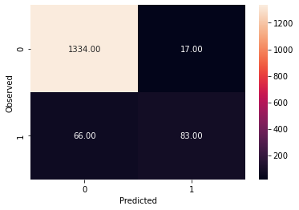

```
None

Recall: 0.5570469798657718

Precision: 0.83

F1 Score: 0.6666666666666666

Roc Auc Score: 0.7722318541075713
```

```python
print("Trainig accuracy",model.score(X_train,y_train))
print()
print("Testing accuracy",model.score(X_test, y_test))
print()
print('Confusion Matrix')
print(draw_cm(y_test,y_predict))
print()
print("Recall:",recall_score(y_test,y_predict))
print()
print("Precision:",precision_score(y_test,y_predict))
print()
print("F1 Score:",f1_score(y_test,y_predict))
print()
print("Roc Auc Score:",roc_auc_score(y_test,y_predict))
```

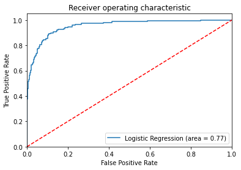

```python
#AUC ROC curve
from sklearn.metrics import roc_auc_score
from sklearn.metrics import roc_curve

logit_roc_auc = roc_auc_score(y_test, model.predict(X_test))
fpr, tpr, thresholds = roc_curve(y_test, model.predict_proba(X_test)[:,1])
plt.figure()
plt.plot(fpr, tpr, label='Logistic Regression (area = %0.2f)' % logit_roc_auc)
plt.plot([0, 1], [0, 1],'r--')
plt.xlim([0.0, 1.0])
plt.ylim([0.0, 1.05])
plt.xlabel('False Positive Rate')
plt.ylabel('True Positive Rate')
plt.title('Receiver operating characteristic')
plt.legend(loc="lower right")
plt.savefig('Log_ROC')
plt.show()
```

## Give your reasoning on how can the model perform better?

```python
# Checking Parameters of logistic regression
model.get_params()

#If we dont specify the parameters in the model it takes default value
```

```
{'C': 1.0,
 'class_weight': None,
 'dual': False,
 'fit_intercept': True,
 'intercept_scaling': 1,
 'l1_ratio': None,
 'max_iter': 100,
 'multi_class': 'auto',
 'n_jobs': None,
 'penalty': 'l2',
 'random_state': None,
 'solver': 'liblinear',
 'tol': 0.0001,
 'verbose': 0,
 'warm_start': False}
```

```python
# Running a loop to check different values of 'solver'
# all solver can be used with l2, only 'liblinear' and 'saga' works with both 'l1' and 'l2'

train_score=[]
test_score=[]
solver = ['newton-cg','lbfgs','liblinear','sag','saga']
for i in solver:
    model = LogisticRegression(random_state=42,penalty='l2', C = 0.75,solver=i)  # changing values of solver
    model.fit(X_train, y_train)
    y_predict = model.predict(X_test)
    train_score.append(round(model.score(X_train, y_train),3))
    test_score.append(round(model.score(X_test, y_test),3))

print(solver)
print()
print(train_score)
print()
print(test_score)
```

```
['newton-cg', 'lbfgs', 'liblinear', 'sag', 'saga']

[0.953, 0.951, 0.951, 0.937, 0.929]

[0.947, 0.944, 0.945, 0.933, 0.926]
```

```python
train_score=[]
test_score=[]
solver = ['liblinear','saga']   # changing values of solver which works with 'l1'
for i in solver:
    model = LogisticRegression(random_state=42,penalty='l1', C = 0.75,solver=i)  #changed penalty to 'l1'
    model.fit(X_train, y_train)
    y_predict = model.predict(X_test)
    train_score.append(round(model.score(X_train, y_train),3))
    test_score.append(round(model.score(X_test, y_test),3))

print(solver)
print()
print(train_score)
print()
print(test_score)
```

```
['liblinear', 'saga']

[0.951, 0.929]

[0.948, 0.925]
```

#### Highest accuracy is same 'l1' with 'liblinear' and 'l2' with 'newton-cg' [choose any one]

```python
# Running a loop to check different values of 'C'

train_score=[]
test_score=[]
C = [0.01,0.1,0.25,0.5,0.75,1]
for i in C:
    model = LogisticRegression(random_state=42,penalty='l1', solver='liblinear', C=i)  # changing values of C
    model.fit(X_train, y_train)
    y_predict = model.predict(X_test)
    train_score.append(round(model.score(X_train,y_train),3)) # appending training accuracy in a blank list for every run of the loop
    test_score.append(round(model.score(X_test, y_test),3))   # appending testing accuracy in a blank list for every run of the loop

print(C)
print()
print(train_score)
print()
print(test_score)
```

```
[0.01, 0.1, 0.25, 0.5, 0.75, 1]

[0.922, 0.95, 0.953, 0.951, 0.951, 0.952]

[0.921, 0.944, 0.943, 0.946, 0.948, 0.947]
```

#### Best testing accuracy is obtained for C=0.75

```
Trainig accuracy 0.9511428571428572

Testing accuracy 0.948

Confusion Matrix
```

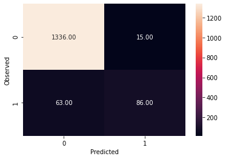

```
None

Recall: 0.5771812080536913

Precision: 0.8514851485148515

F1 Score: 0.688

Roc Auc Score: 0.7830391606515681
```

```python
#Therefore final model is
model = LogisticRegression(random_state=42,penalty='l1', solver='liblinear', C=0.75)
model.fit(X_train, y_train)
y_predict = model.predict(X_test)
print("Trainig accuracy",model.score(X_train,y_train))
print()
print("Testing accuracy",model.score(X_test, y_test))
print()
print('Confusion Matrix')
print(draw_cm(y_test,y_predict))
print()
print("Recall:",recall_score(y_test,y_predict))
print()
print("Precision:",precision_score(y_test,y_predict))
print()
print("F1 Score:",f1_score(y_test,y_predict))
print()
print("Roc Auc Score:",roc_auc_score(y_test,y_predict))
```

```python
!pip install yellowbrick
```

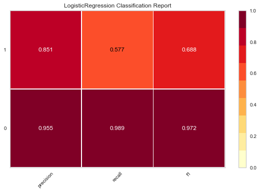

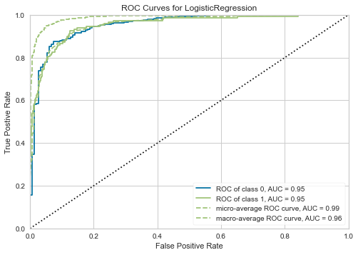

```python
# Additional

from yellowbrick.classifier import ClassificationReport, ROCAUC
# Visualize model performance with yellowbrick library
viz = ClassificationReport(model)
viz.fit(X_train, y_train)
viz.score(X_test, y_test)
viz.show()

roc = ROCAUC(model)
roc.fit(X_train, y_train)
roc.score(X_test, y_test)
roc.show()
```

## Give Business understanding of your model?

**Confusion matrix means**

*True Positive (observed=1,predicted=1):*

Predicted that customer will take personal loan and the customer took the loan

*False Positive (observed=0,predicted=1):*

Predicted that customer will take personal loan and the customer did not take the loan

*True Negative (observed=0,predicted=0):*

Predicted that customer will not take personal loan and the customer did not take the loan

*False Negative (observed=1,predicted=0):*

Predicted that customer will not take personal loan and the customer took the loan

Here the bank wants to give loan to the people who are interested in the personal loan i.e. less number of False Positive, if FP is high bank would lose money. So that the bank doesn't lose money on the people who are not interested for the loan. Hence Precision is the important metric.

In case of False negative bank will lose few customers but that okay because the bank is not loosing money it is just a small oppertunity cost.

After achieving the desired accuracy we can deploy the model for practical use. As in the bank now can predict who is interested for personal loan. They can use the model for upcoming customers.